# Coursera Practical Machine Learning Course Project

## Summary

The project assignment was to look at data coming from accelerometers and predict the type of movement a person is doing from the movement data captured by their device. In this study the movements were known and the data was classified based on the known activity.

## Getting and Cleaning Data

Two data sets were provided, one with testing data and another with training. In reality the testing data was not true testing data as it did not have the outcome. In order to ensure proper cross validaiton was done, the first step then was to separate the training data into training and testing sets so that out of sample error could be measured. Once that was complete I began analysis on the training data set. Looking at the data there 160 variables, but a large number of them appeared to be mostly empty (str funtion call omitted for brevity). Here are two examples:

```r
set.seed(302)
nrow(training2)
```

```
## [1] 14718
```

```r
table(training2$max_roll_dumbbell=="")
```

```
##
## FALSE
##   307
```

```r
table(is.na(training2$var_accel_forearm)   )
```

```
##
## FALSE  TRUE
##   307 14411
```

From the above we can see that out of the ~14000 observations only around 300 of them have values that are not NA or blank. I went ahead and removed all columns that had this issue leaving me with a dataset with 53 columns including the outcome.

# Principal Component analysis

Given that are a lot of features in this dataset the next step was to figure out which ones were the most important. To that end I ran a principal components analysis. The following results were given:

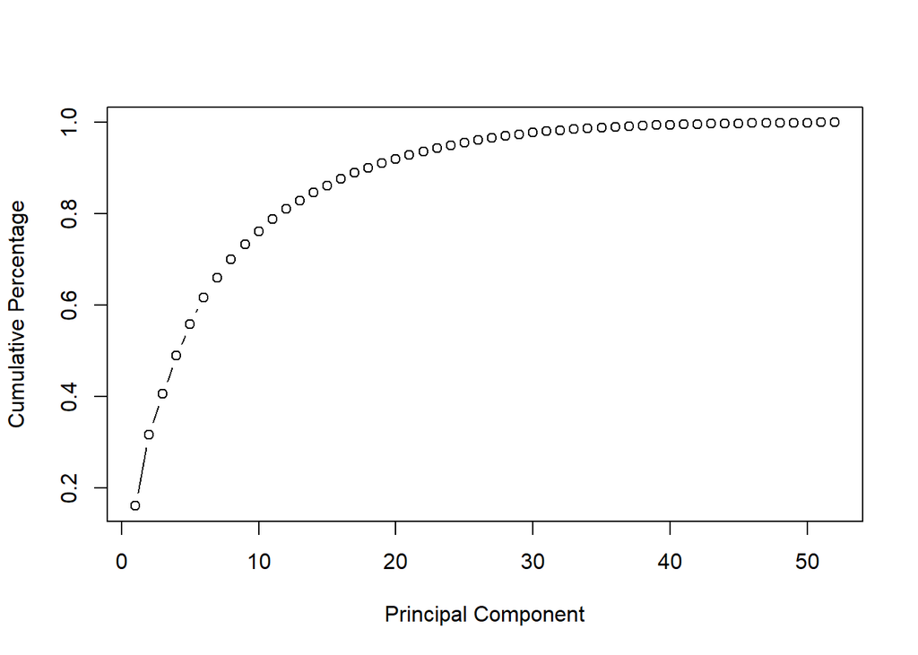

```r
pca1<-prcomp(training3[,-53], scale=TRUE)
varr <- pca1$sdev^2
percvar <- varr/sum(varr)
prinComp<- pca1$x
plot(cumsum(percvar), xlab = "Principal Component",
     ylab = "Cumulative Percentage",
     type = "b")
```

## Model - Random Forest

The next step was to run a random forest model, fit the pca and the model to the test set and measure the out of sample error.

```r
library(randomForest)
fit<- randomForest(x=prinComp[,1:30],y=training3$classe)
testing2<-  predict(pca1,newdata=testing)
pred1<-predict(fit, testing2[,1:30])
confusionMatrix(pred1, testing$classe)
```

```
## Confusion Matrix and Statistics
##
##           Reference
## Prediction    A    B    C    D    E
##          A 1389   18    3    0    0
##          B    3  918   12    0    7
##          C    0   13  830   14   10
##          D    3    0    8  784    8
##          E    0    0    2    6  876
##
## Overall Statistics
##
##                Accuracy : 0.9782
##                  95% CI : (0.9737, 0.9821)
##     No Information Rate : 0.2845
##     P-Value [Acc > NIR] : < 2.2e-16
##
##                   Kappa : 0.9724
##  Mcnemar's Test P-Value : NA
##
## Statistics by Class:
##
##                      Class: A Class: B Class: C Class: D Class: E
## Sensitivity            0.9957   0.9673   0.9708   0.9751   0.9723
## Specificity            0.9940   0.9944   0.9909   0.9954   0.9980
## Pos Pred Value         0.9851   0.9766   0.9573   0.9763   0.9910
## Neg Pred Value         0.9983   0.9922   0.9938   0.9951   0.9938
## Prevalence             0.2845   0.1935   0.1743   0.1639   0.1837
## Detection Rate         0.2832   0.1872   0.1692   0.1599   0.1786
## Detection Prevalence   0.2875   0.1917   0.1768   0.1637   0.1803
## Balanced Accuracy      0.9949   0.9809   0.9808   0.9852   0.9851
```

[figure not shown]

## Conclusion

In order to predict the class based on the movement data I first separated the training data into training and testing sets so I could measure the out of sample error. I then used the training data to profile the data and remove columns were low information.

Since I had a large number of features I chose principal components analysis to get a better sense of the variance explained by each feature and chose the top 30 principal components. Finally, because I had a dataset with a large number of features and a categorical outcome I used a random forest as my prediction algorithm. I evalated that against the test set I created earlier and was happy with the small out of sample error.